# 빅 콘테스트

Jong Soo

2019 9 9

### *팀명 : 에어플레인모드*

#### 팀원 : 이재원, 황종수, 손희헌, 이소정

# **목차** .

- 1. EDA
- 2. 전처리 및 파생변수 생성
- 3. 분석

# 1. EDA (탐색적 데이터 분석)

```r
rm(list=ls())
AFSNT <- read.csv("C:/Users/lan41/OneDrive/바탕 화면/0909/AFSNT.csv")
AFSNT_DLY <- read.csv("C:/Users/lan41/OneDrive/바탕 화면/0909/AFSNT_DLY.csv")
AFSNT$dly <- as.numeric(AFSNT$DLY=="Y")
{
  AFSNT$SDT_YY <- as.factor(AFSNT$SDT_YY)
  AFSNT$SDT_MM <- as.factor(AFSNT$SDT_MM)
  AFSNT$SDT_DY <- as.factor(AFSNT$SDT_DY)
}
```

## 데이터 크기 확인

```r
# 결측치 확인
apply(is.na(AFSNT),MARGIN = 2 , FUN = "sum")
```

```
## SDT_YY SDT_MM SDT_DD SDT_DY    ARP    ODP    FLO    FLT    REG    AOD
##      0      0      0      0      0      0      0      0      0      0
##    IRR    STT    ATT    DLY    DRR    CNL    CNR    dly
##      0      0      0      0      0      0      0      0
```

```r
dim(AFSNT)
```

```
## [1] 987709     18
```

```r
summarizeColumns(AFSNT)[,c(1,2,10)]
```

```
##      name    type nlevs
## 1  SDT_YY  factor     3
## 2  SDT_MM  factor    12
## 3  SDT_DD integer     0
## 4  SDT_DY  factor     7
## 5     ARP  factor    15
## 6     ODP  factor    15
## 7     FLO  factor    12
## 8     FLT  factor  1541
## 9     REG  factor   364
## 10    AOD  factor     2
## 11    IRR  factor     2
## 12    STT  factor   372
## 13    ATT  factor  1159
## 14    DLY  factor     2
## 15    DRR  factor    37
## 16    CNL  factor     2
## 17    CNR  factor    24
## 18    dly numeric     0
```

#### EDA 사용자 함수 생성

```r
EDA1 = function(x){
  temp <- AFSNT[,x] %>%
    table() %>%
    data.frame()
  colnames(temp) <- c("variable","N")
  temp2 <- temp %>%
    ggplot(aes(x=variable, y=N,fill=variable))+
    geom_bar(stat='identity')+ ggtitle(x)
  if (max(nchar(as.character(temp[,1])))>= 5){
    return(temp2 +
    theme(axis.text.x=element_text(angle=45, hjust=1)))
  }
  else return(temp2)
}

guides_size = function(x){
  return(guides(fill = guide_legend(keywidth = x, keyheight = x)))
}
```

## 날짜 관련된 변수 빈도 살펴보기

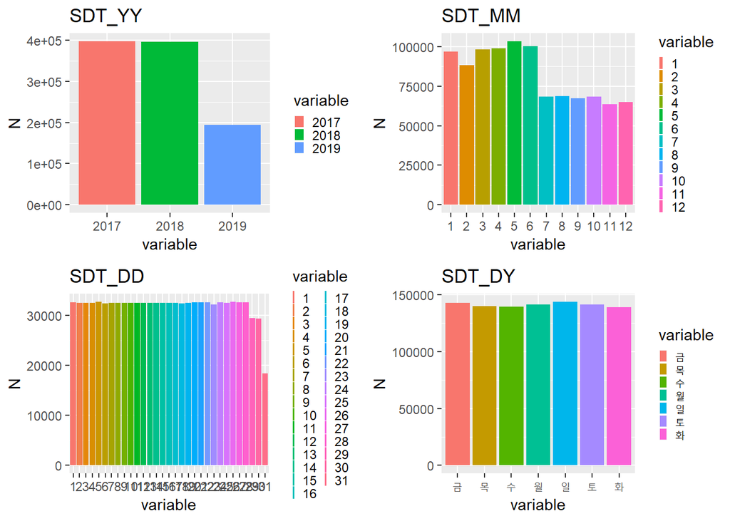

```r
grid.arrange(EDA1("SDT_YY")+guides_size(0.5),EDA1("SDT_MM")+guides_size(0.2),
             EDA1("SDT_DD")+guides_size(0.1),EDA1("SDT_DY")+guides_size(0.4),
             nrow = 2 , ncol = 2)
```

- 데이터가 2017~2019.6 까지의 데이터라서 7~12월 빈도수가 상대적으로 부족함 . (월별로 운항횟수를 체크 해보아야 할 것 같다. )
- 골고루 분포되어있음을 알수있음

## 연도그룹간 월별 운행횟수 살펴보기

빈도 표에 약간의 빈도 차이가 있어서 확인 해 보았다 .

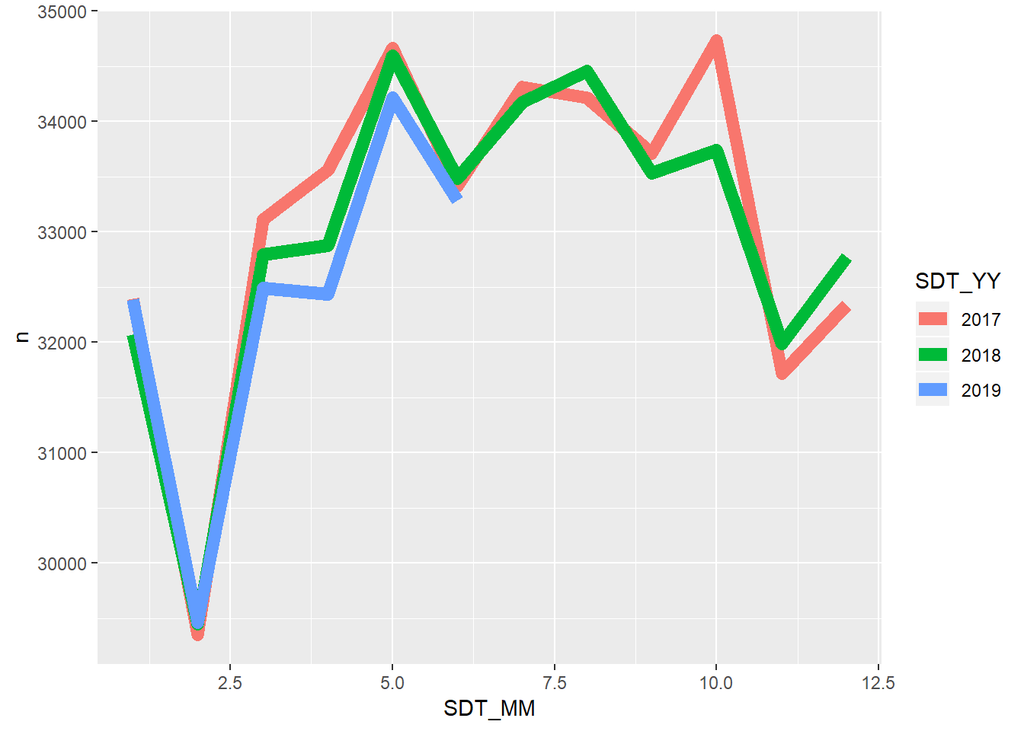

```r
AFSNT %>% group_by(SDT_YY,SDT_MM) %>% summarise(n=n())-> tempdf1
tempdf1$SDT_YY <- as.factor(tempdf1$SDT_YY)
tempdf1$SDT_MM <- as.numeric(tempdf1$SDT_MM)
ggplot(tempdf1, aes(x=SDT_MM,y=n,color=SDT_YY)) + geom_line(size=3)
```

년도마다 운행횟수는 같은 패턴을 가짐을 알 수 있었다 .

## 공항 관련 변수 살펴보기

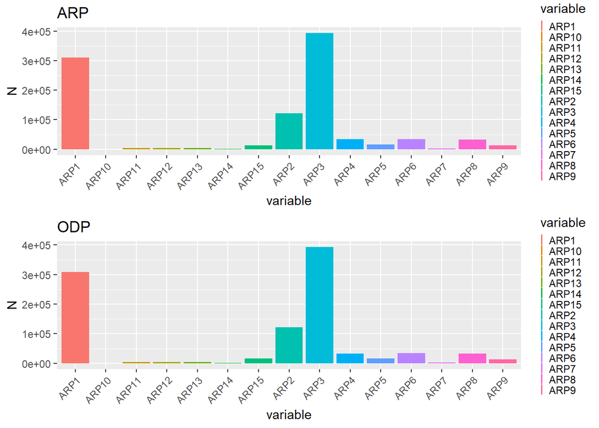

```r
grid.arrange(EDA1("ARP")+guides_size(0.1),EDA1("ODP")+guides_size(0.1),
             nrow=2)
```

- ARP3 공항에서 가장 많은 운행 기록이 있었음을 알 수 있다.
- 다음으로는 ARP1 ARP2 와 작은 공항들이 있음을 알 수 있다 .
- 공항마다 지연여부의 차이가 있는지를 생각해보아야겠다 .
- 운행 정보가 거의 없는 공항들도 있었다 .

## 그 외 나머지 변수들 살펴보기

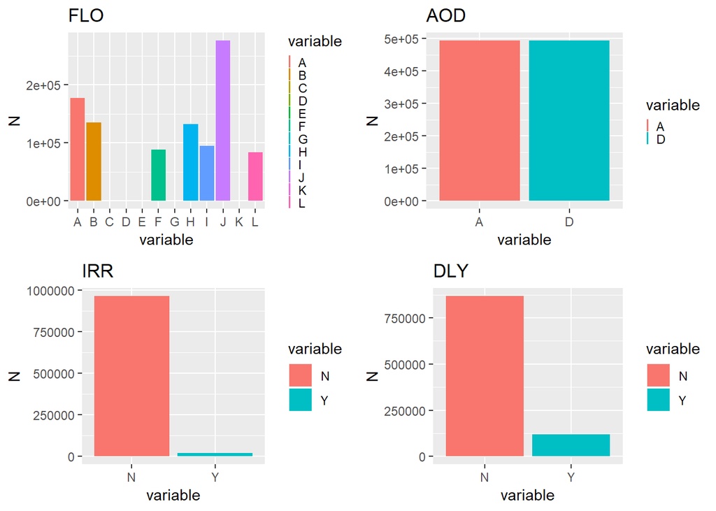

```r
grid.arrange(EDA1("FLO")+guides_size(0.1),EDA1("AOD")+guides_size(0.1),
             EDA1("IRR"),EDA1("DLY"),ncol=2)
```

```r
table(AFSNT$DLY)/nrow(AFSNT)    # 지연 12퍼센트
```

```
##
##        N        Y
## 0.879583 0.120417
```

- 먼저 항공사 변수를 살펴보자면 J항공사의 운항횟수가 월등히 많았고 , 그 뒤를 이어서 A, B, H 항공사 정도가 있었다 . 5개의 항공사 (C,D,E,G,K) 는 운항횟수가 거의 없었다 .
- 출도착은 거의 같은 비율이었고 , 출 도착별로 특징이 다른지 구분 해 봐야겠다 .
- 부정기편은 진짜 거의 없는 편 .
- 지연 운행은 전체 데이터의 12퍼센트 정도 . ( 출발 도착이 다른지 체크해보자 )

# 지연 여부와 관련하여서 보기

# 변수 레벨에 따라 평균 지연율을 관찰 해보자 .

### 출발 도착을 구분하여 살펴보기

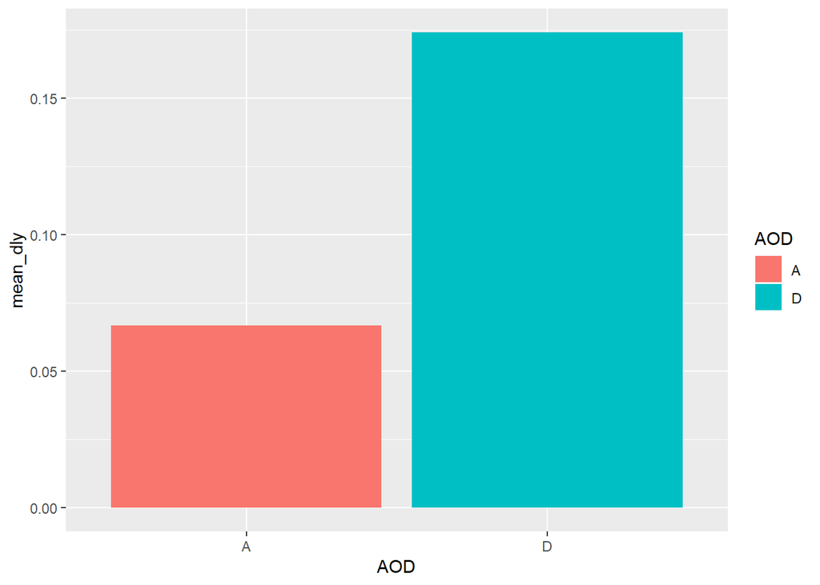

```r
AFSNT %>% group_by(AOD) %>% summarise(mean_dly=mean(dly)) %>% ggplot(aes(x=AOD,y=mean_dly,fill=AOD)) + geom_bar(stat="identity")
```

- 출발 도착 구분간에 평균 지연율이 큰 차이를 보였다 .
- 이러한 점과 나중에 모델에 적용시킬 때 더 좋은 성능을 보일 것으로 생각하여 이제 출발 도착 데이터를 나눠서 분석 해보도록 하겠다 .

## 연도 별 평균 지연율 살펴보기

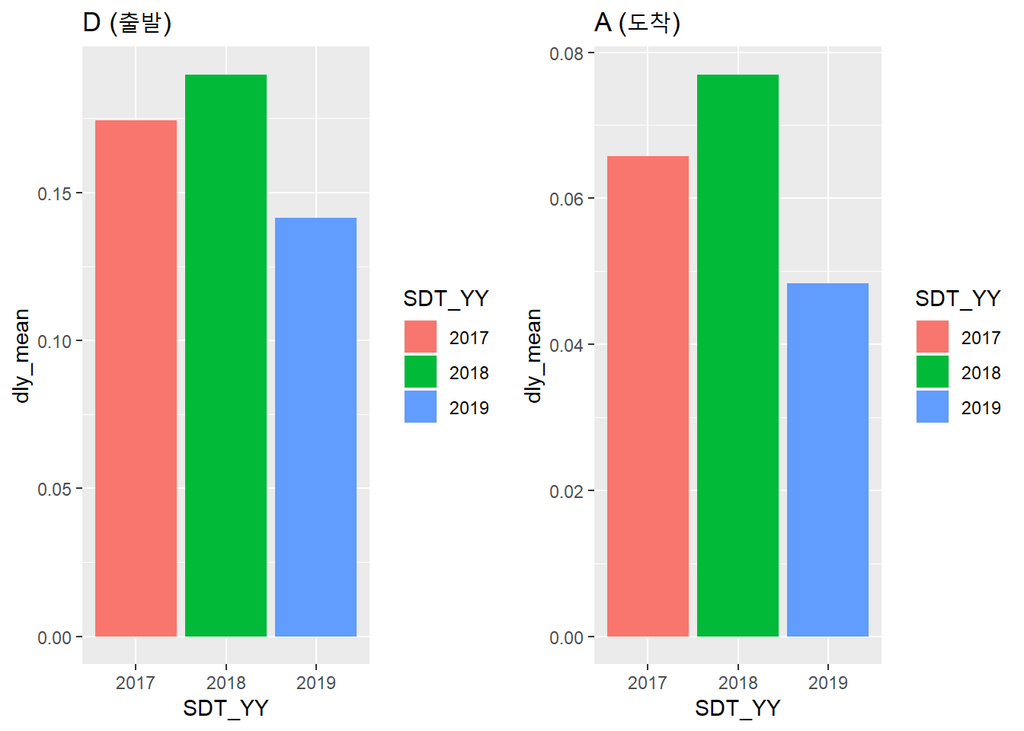

```r
# 출발
AFSNT %>% filter(AOD == "D") %>% group_by(SDT_YY) %>% summarise(dly_mean = mean(dly)) %>% ggplot(aes(x=SDT_YY,y=dly_mean,fill=SDT_YY)) + geom_bar(stat="identity") + ggtitle("D (출발)")-> g1
# 도착
AFSNT %>% filter(AOD == "A") %>% group_by(SDT_YY) %>% summarise(dly_mean = mean(dly)) %>% ggplot(aes(x=SDT_YY,y=dly_mean,fill=SDT_YY)) + geom_bar(stat="identity") + ggtitle("A (도착)")-> g2

grid.arrange(g1,g2,ncol=2)
```

- (출발 도착 공통)
- 2018년도에 지연율이 가장 높았음을 알 수 있다 .
- 2019년도에는 지연율이 비교적 낮은편 .
- (다른 점)
- 출발 운행 정보에서 평균 지연율이 비교적 더 높았다 .

## 월 별 평균 지연율 살펴보기

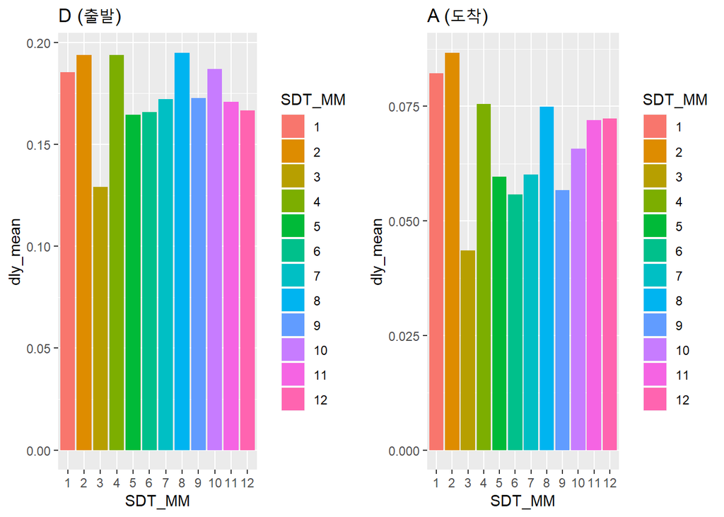

```r
# 출발
AFSNT %>% filter(AOD == "D") %>% group_by(SDT_MM) %>% summarise(dly_mean = mean(dly)) %>% ggplot(aes(x=SDT_MM,y=dly_mean,fill=SDT_MM)) + geom_bar(stat="identity") + ggtitle("D (출발)") -> g1
# 도착
AFSNT %>% filter(AOD == "A") %>% group_by(SDT_MM) %>% summarise(dly_mean = mean(dly)) %>% ggplot(aes(x=SDT_MM,y=dly_mean,fill=SDT_MM)) + geom_bar(stat="identity") + ggtitle("A (도착)")-> g2

grid.arrange(g1,g2,ncol=2)
```

- 3월의 평균 지연율이 가장 낮았고 , 1,2,4,8 월의 평균 지연율이 높은 편이었다 .
- 도착에서의 평균 지연율은 출발에 비해 낮았다 .

## 요일 별 평균 지연율 살펴보기

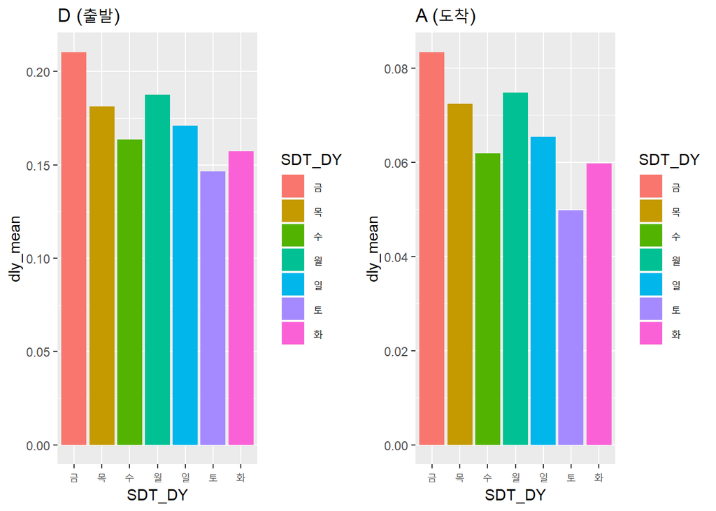

```r
# 출발
AFSNT %>% filter(AOD == "D") %>% group_by(SDT_DY) %>% summarise(dly_mean = mean(dly)) %>% ggplot(aes(x=SDT_DY,y=dly_mean,fill=SDT_DY)) + geom_bar(stat="identity") + ggtitle("D (출발)") -> g1
# 도착
AFSNT %>% filter(AOD == "A") %>% group_by(SDT_DY) %>% summarise(dly_mean = mean(dly)) %>% ggplot(aes(x=SDT_DY,y=dly_mean,fill=SDT_DY)) + geom_bar(stat="identity") + ggtitle("A (도착)")-> g2

grid.arrange(g1,g2,ncol=2)
```

- 요일 별로 지연율 평균이 다르다는 것을 확인 하였다 .
- 금요일 평균 지연율이 가장 높았고 , 토요일이 가장 낮은 것을 확인 하였다.

## 공항 별 평균 지연율 살펴보기

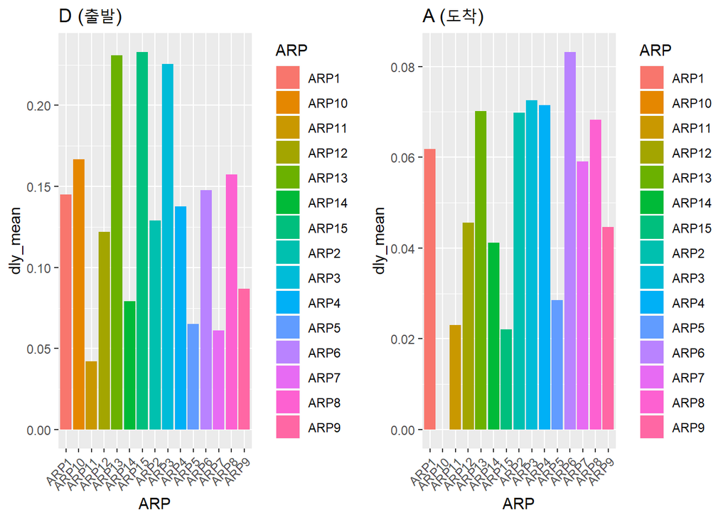

```r
# 출발
AFSNT %>% filter(AOD == "D") %>% group_by(ARP) %>% summarise(dly_mean = mean(dly)) %>% ggplot(aes(x=ARP,y=dly_mean,fill=ARP)) + geom_bar(stat="identity") + ggtitle("D (출발)") + theme(axis.text.x=element_text(angle=45, hjust=1)) -> g1
# 도착
AFSNT %>% filter(AOD == "A") %>% group_by(ARP) %>% summarise(dly_mean = mean(dly)) %>% ggplot(aes(x=ARP,y=dly_mean,fill=ARP)) + geom_bar(stat="identity") + ggtitle("A (도착)") + theme(axis.text.x=element_text(angle=45, hjust=1))-> g2

grid.arrange(g1,g2,ncol=2)
```

- 공항마다 지연율 차이가 심하게 나는 것을 확인 하였다.
- 공항마다의 지연율은 출도착에 따라서 많이 다름을 알 수 있었다 .
- ARP13 , ARP3 공항에서 평균 지연율이 높은 편이었고 , ARP11 공항에서 낮은 편이었다 .

## 상대공항 별 평균 지연율 살펴보기

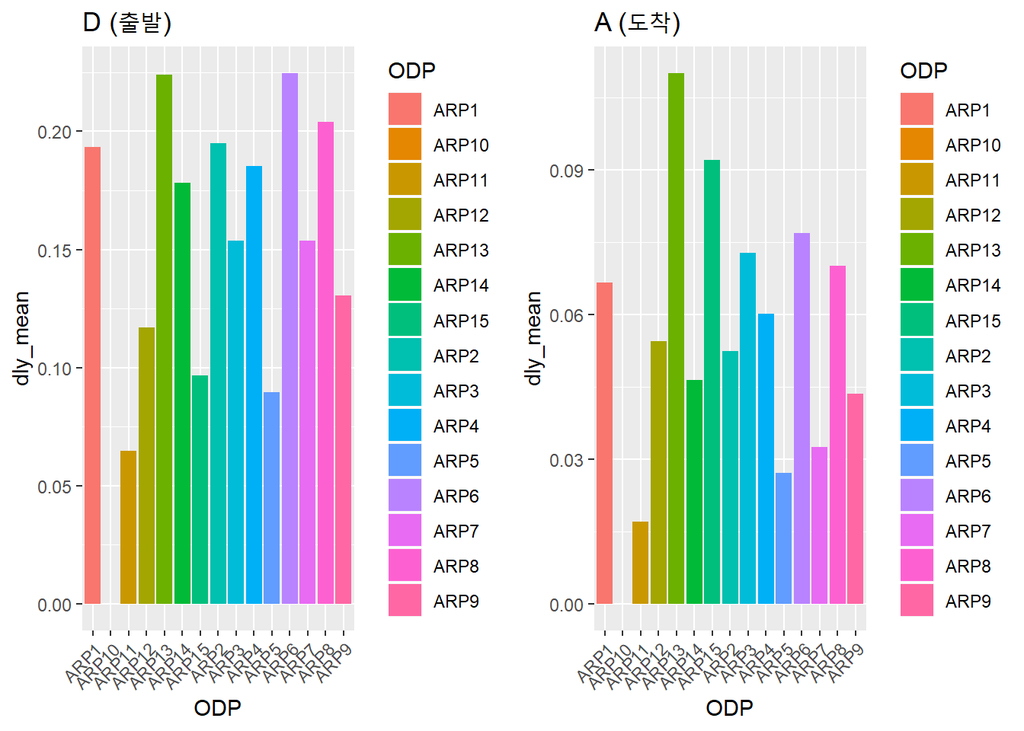

```r
# 출발
AFSNT %>% filter(AOD == "D") %>% group_by(ODP) %>% summarise(dly_mean = mean(dly)) %>% ggplot(aes(x=ODP,y=dly_mean,fill=ODP)) + geom_bar(stat="identity") + ggtitle("D (출발)") + theme(axis.text.x=element_text(angle=45, hjust=1)) -> g1
# 도착
AFSNT %>% filter(AOD == "A") %>% group_by(ODP) %>% summarise(dly_mean = mean(dly)) %>% ggplot(aes(x=ODP,y=dly_mean,fill=ODP)) + geom_bar(stat="identity") + ggtitle("A (도착)") + theme(axis.text.x=element_text(angle=45, hjust=1))-> g2

grid.arrange(g1,g2,ncol=2)
```

- 상대 공항마다 평균 지연율이 차이 나는 것을 확인 하였다.
- 상대공항이 ARP13 인 운행에서 평균 지연율이 높은 것을 확인.
- 상대공항이 ARP11 , ARP5 인 운행에서는 평균 지연율이 낮은 것을 확인 .

## 항공사 별 평균 지연율 살펴보기

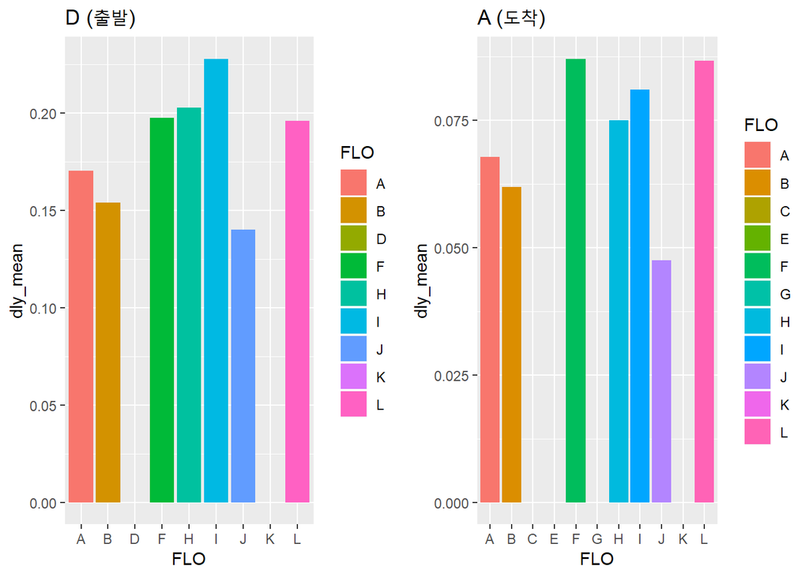

```r
# 출발
AFSNT %>% filter(AOD == "D") %>% group_by(FLO) %>% summarise(dly_mean = mean(dly)) %>% ggplot(aes(x=FLO,y=dly_mean,fill=FLO)) + geom_bar(stat="identity") + ggtitle("D (출발)")  -> g1
# 도착
AFSNT %>% filter(AOD == "A") %>% group_by(FLO) %>% summarise(dly_mean = mean(dly)) %>% ggplot(aes(x=FLO,y=dly_mean,fill=FLO)) + geom_bar(stat="identity") + ggtitle("A (도착)")  -> g2

grid.arrange(g1,g2,ncol=2)
```

- 항공사 별 평균 지연율이 다른 것을 확인 . (출발)
- I 항공사에서 평균 지연율이 가장 높았고 , J 항공사에서 평균 지연율이 가장 낮았다 . 앞에서 본 빈도에 비교해 보면 , J 항공사는 운항횟수가 가장 많지만 평균 지연 확률은 가장 낮음을 알 수 있다 . (도착)
- F 항공사와 L 항공사의 지연율 평균이 가장 높았다.

## 부정기편 별 평균 지연율 살펴보기

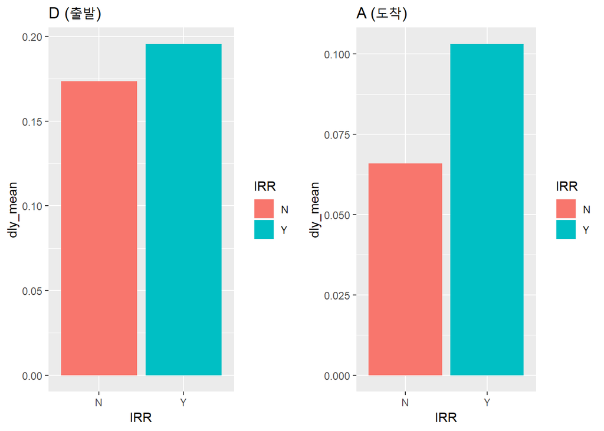

```r
# 출발
AFSNT %>% filter(AOD == "D") %>% group_by(IRR) %>% summarise(dly_mean = mean(dly)) %>% ggplot(aes(x=IRR,y=dly_mean,fill=IRR)) + geom_bar(stat="identity") + ggtitle("D (출발)")  -> g1
# 도착
AFSNT %>% filter(AOD == "A") %>% group_by(IRR) %>% summarise(dly_mean = mean(dly)) %>% ggplot(aes(x=IRR,y=dly_mean,fill=IRR)) + geom_bar(stat="identity") + ggtitle("A (도착)")  -> g2

grid.arrange(g1,g2,ncol=2)
```

- 출발 도착 둘다 부정기편에서의 평균 지연율이 더 높았다 .

# 2. 전처리 및 파생변수 생성

## 시간 정보 변수 생성

```r
AFSNT$STT_hour <- sapply(strsplit(as.character(AFSNT$STT),":"),"[",1)
AFSNT$STT_minute <- sapply(strsplit(as.character(AFSNT$STT),":"),"[",2)
AFSNT$ATT_hour <- sapply(strsplit(as.character(AFSNT$ATT),":"),"[",1)
AFSNT$ATT_minute <- sapply(strsplit(as.character(AFSNT$ATT),":"),"[",2)
AFSNT$STT2 <- as.numeric(AFSNT$STT_hour) + as.numeric(AFSNT$STT_minute)/60
AFSNT$ATT2 <- as.numeric(AFSNT$ATT_hour) + as.numeric(AFSNT$ATT_minute)/60
AFSNT$date <- ymd(paste(AFSNT$SDT_YY,AFSNT$SDT_MM,AFSNT$SDT_DD))

# 계획 시간을 반올림 한 변수
AFSNT$STT3 <- as.factor(round(AFSNT$STT2))

# 실제 지연 시간 (아주 작은 음의 값으로 나타난 경우는 나중에 전처리 과정에서 다 삭제 됨.)
AFSNT$delay_time <- AFSNT$ATT2 - AFSNT$STT2
```

- 공항 그룹 별 해당 시간당 운행 횟수 별 지연확률을 살펴보자.

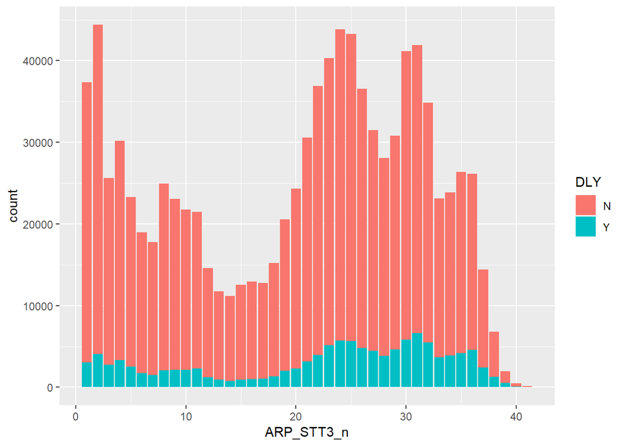

```r
# 해당 날짜의 공항에 시간당 운항 개수를 담은 파생 변수
AFSNT %>% group_by(date,ARP,STT3) %>% summarise(n=n()) -> temp1
AFSNT$temp <- paste(AFSNT$date,AFSNT$ARP,AFSNT$STT3)
temp1$temp <- paste(temp1$date,temp1$ARP,temp1$STT3)
temp2 <- unique(temp1$n)
for(i in temp2){
  tempinfo <- temp1$temp[temp1$n==i]
  AFSNT$ARP_STT3_n[AFSNT$temp %in% tempinfo] <- i
  # print(i)
}
AFSNT$temp <- NULL
rm(temp1,temp2,tempinfo)

ggplot(AFSNT,aes(x=ARP_STT3_n,fill=DLY))+geom_bar()
```

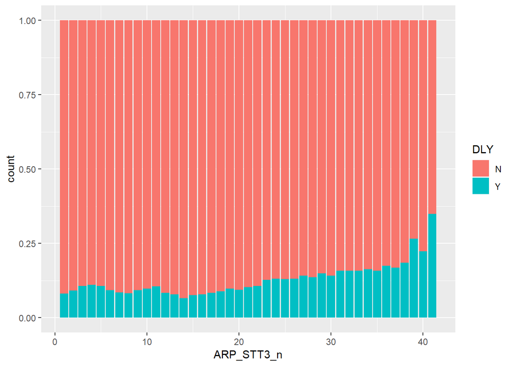

```r
ggplot(AFSNT,aes(x=ARP_STT3_n,fill=DLY))+geom_bar(position="fill")
```

- 해당 시간 공항의 비행기 운항 정보가 많을 수록 평균 지연율은 증가하는 것을 볼 수 있다.

## 제출 데이터에 없는 편명은 지우기

```r
# 987,709 rows -> 859,930 rows (127,779 rows deleted)
AFSNT %>% filter(FLT %in% unique(AFSNT_DLY$FLT)) -> AFSNT
dim(AFSNT)
```

```
## [1] 859930     28
```

## 부정 기편 및 결항 제거

```
## [1] 850625     28
```

## 제출 데이터에 계획시간 외에는 제거

```r
# 850,625 rows -> 850,609 rows (16 rows deleted)
AFSNT$hm_STT <- hm(AFSNT$STT)
AFSNT %>% filter(hm_STT >= hm("06:00") & hm_STT <= hm("23:00")) -> AFSNT
dim(AFSNT)
```

```
## [1] 850609     29
```

## 이상치 제거

```r
# 단순 오타 추정

# 이상치 제거
# 지연 시간 이상치
# 850,609 rows -> 850,588 rows  ( 21 rows deleted )
AFSNT %>% filter(!delay_time %in% sort(AFSNT$delay_time)[1:21]) -> AFSNT

# 850,588 rows -> 849,151 rows ( 1,437 rows deleted )
# 지연 시간이 3시간 이상인 것들은 이상치로 판단
AFSNT %>% filter(delay_time <3) -> AFSNT

# 제주도 활주로 비행기 사고
# 849,151 rows -> 848,270 rows ( 881 rows deleted )
AFSNT %>% filter(date != ymd("20170929")) -> AFSNT

dim(AFSNT)
```

```
## [1] 848270     29
```

## 출도착 안맞는거 제거

```r
# 출발 또는 도착만 존재하는 데이터 지우기
# 설날 처럼 특수한 날에 한 편명이 두번 출발 했던 날과 출 도착이 안 맞는 데이터 삭제
# 848,270 rows -> 847,946 rows ( 324 rows deleted )
AFSNT %>%
  group_by(FLT,SDT_YY,SDT_MM,SDT_DD) %>%
  summarise(n=n()) %>%
  filter(n==1 | n==4) %>%
  as.data.frame()-> temp

index <- NULL
for( i in 1:nrow(temp) ){
  index <- c(index,which((AFSNT$SDT_YY==temp$SDT_YY[i]) & (AFSNT$SDT_MM==temp$SDT_MM[i]) & (AFSNT$SDT_DD==temp$SDT_DD[i]) & (AFSNT$FLT==temp$FLT[i])))
  # print(i)
}
AFSNT <- AFSNT[-index,]

dim(AFSNT)
```

```
## [1] 847946     29
```

# 계획 시간 별 지연 상황 살펴보기

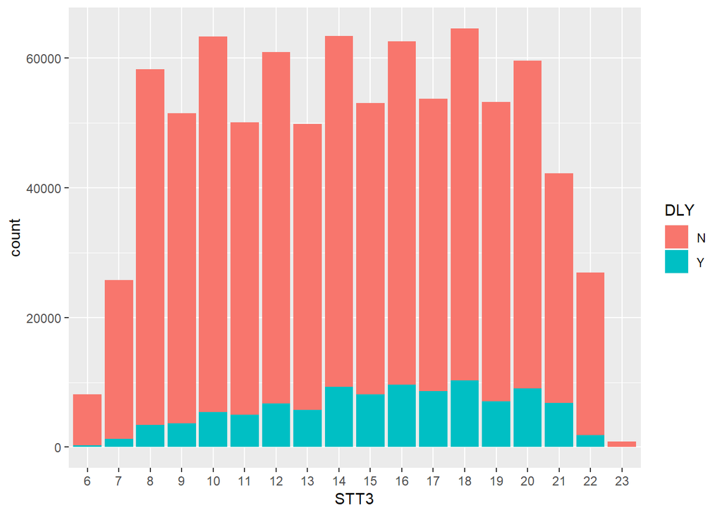

```r
ggplot(AFSNT,aes(x=STT3,fill=DLY)) + geom_bar()
```

- 계획시간마다 운항수가 달라서 지연율을 보기 위해 비율만 보기로 하였다.

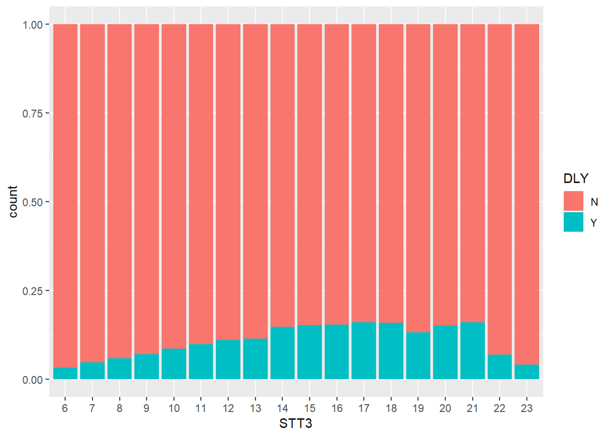

```r
ggplot(AFSNT,aes(x=STT3,fill=DLY)) + geom_bar(position = "fill")
```

- 계획 시간에 따라 지연율이 다르다 . 계획 시간이 지연율에 영향이 있다 .

# 외생 변수 추가

- 항공 기상 날씨 데이터

```r
weather=read.csv("C:/Users/lan41/OneDrive/바탕 화면/0909/weather.csv",header=T) #날씨데이터
weather$date <- paste0(sprintf("%04d",weather$yyyy),sprintf("%02d",weather$mm),sprintf("%02d",weather$dd))

AFSNT$date0 <- paste0(sprintf("%04d",as.numeric(as.character(AFSNT$SDT_YY))),sprintf("%02d",as.numeric(as.character(AFSNT$SDT_MM))),sprintf("%02d",as.numeric(as.character(AFSNT$SDT_DD))))

AFSNT %>% mutate(wea = ifelse(date0 %in% weather$date, 1, 0)) %>% as.data.frame -> AFSNT
```

기상이 안 좋았던 날과 좋았던 날의 지연율 차이를 살펴보았다.

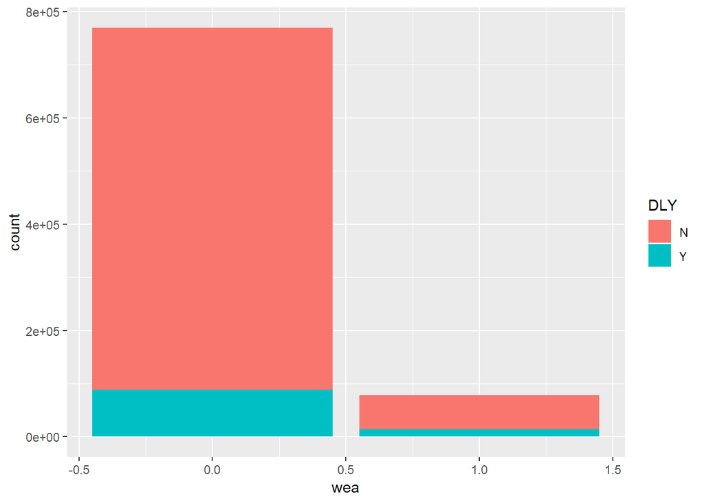

```r
ggplot(AFSNT,aes(x=wea,fill=DLY)) + geom_bar()
```

기상이 안 좋았던 날과 좋았던 날의 지연율 차이를 살펴보았다.

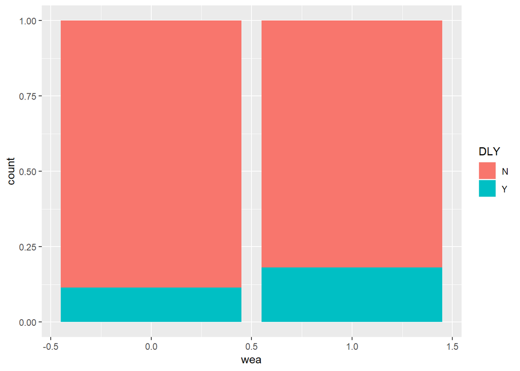

```r
ggplot(AFSNT,aes(x=wea,fill=DLY)) + geom_bar(position = "fill")
```

- 기상이 심했던 날은 지연율이 높은 편이었다 .

## 출 도착 나누기

```r
# A (423.973 rows)
AFSNT %>% filter(AOD=="A") -> A
# D (423.973 rows)
AFSNT %>% filter(AOD=="D") -> D
```

## 편명 그룹 요일 별 평균 지연율 살펴보기

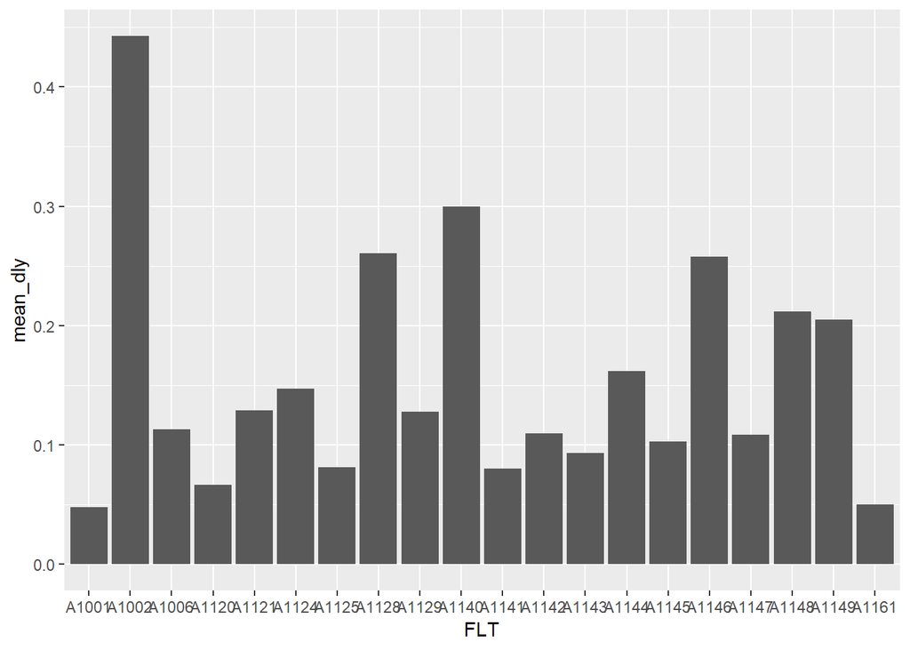

```r
D %>% group_by(FLT) %>% summarise(mean_dly = mean(dly)) -> temp
temp1 <- temp[1:20,]

ggplot(temp1,aes(x=FLT,y=mean_dly))+geom_bar(stat="identity")
```

- 편명 마다의 지연율 차이는 분명히 있다 . 하지만 여기서 더 세분화 해보기로 한다

### 편명 그룹간 요일별 평균 지연율

```r
D %>% group_by(FLT,SDT_DY) %>% summarise(mean_dly=mean(dly),n=n()) -> temp
D %>% group_by(FLT) %>% summarise(mean_dly=mean(dly),n=n()) %>% filter(FLT=="A1002")-> temp2
head(temp)
```

```
## # A tibble: 6 x 4
## # Groups:   FLT [2]
##   FLT   SDT_DY mean_dly     n
##   <fct> <fct>     <dbl> <int>
## 1 A1001 목       0.0145    69
## 2 A1001 월       0.0806    62
## 3 A1001 일       0.0551   127
## 4 A1001 화       0         12
## 5 A1002 목       0.667     51
## 6 A1002 수       0.558     43
```

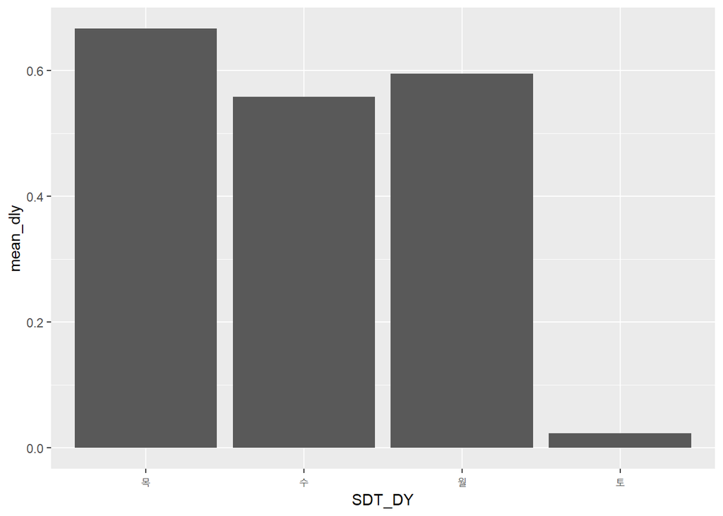

```r
# 편명 A1002 의 평균 지연율은 0.442623 (약 44%)
temp3 <- temp[temp$FLT=="A1002",]

# 하지만 편명 A1002을 요일별로 나눠서 보면 토요일은 지연이 거의 없음을 알 수 있다  .
ggplot(temp3,aes(x=SDT_DY,y=mean_dly)) + geom_bar(stat="identity")
```

- 편명 당 평균 지연율은 물론 있으며 , 같은 편명이라고 해도 요일별로 평균 지연율이 다름을 알 수 있다 .

## 파생 변수 생성

```r
variable_scoring = function(x) {
    # stt ( 계획 시각 별 평균 지연 확률에 대한 변수 )
  x %>% group_by(STT3) %>% summarise(STT_score=round(mean(dly)*10,1)) %>% as.data.frame() -> STT_score

  for(i in 1:nrow(STT_score)){
    x$STT_score[x$STT3==STT_score$STT3[i]] <-  STT_score$STT_score[i]
  }

  # flo ( 항공사 별 평균 지연 확률 에 대한 변수 )
  x %>% group_by(FLO) %>% summarise(FLO_score=round(mean(dly)*10,1)) %>% as.data.frame() -> FLO_score

  for(i in 1:nrow(FLO_score)){
    x$FLO_score[x$FLO==FLO_score$FLO[i]] <-  FLO_score$FLO_score[i]
  }

  # flt ( 편명 그룹 기준 요일 별 평균 지연율에 대한 변수  )
  x %>% group_by(FLT,SDT_DY) %>% summarise(FLT_score=round(mean(dly)*10,1),n=n()) %>% as.data.frame() -> temp_FLT_score

  temp_FLT_score %>% filter(n >= 50) -> temp1
  temp_FLT_score %>% filter(n < 50) -> temp2
  index <- quantile(temp1$FLT_score, probs=c(0,0.2,0.4,0.6,0.8,1))

  temp1 %>% mutate(FLT_rank=ifelse(FLT_score >= index[5],"E",
                                   ifelse(FLT_score >= index[4],"D",
                                          ifelse(FLT_score >= index[3],"C",
                                                 ifelse(FLT_score >= index[2],"B","A"))))) -> temp1

  qt <- quantile(temp2$FLT_score, probs=c(0,0.33,0.66,1))
  temp2 %>% mutate(FLT_rank= ifelse(FLT_score >= qt[3],"D",
                                    ifelse(FLT_score >= qt[2],"C","B"))) -> temp2
  FLT_score <- rbind(temp1,temp2)


  temp_paste1 <- paste(FLT_score$FLT,FLT_score$SDT_DY)
  temp_paste2 <- paste(x$FLT,x$SDT_DY)

  temp_unique <- unique(FLT_score$FLT_rank)

  for(i in temp_unique){
    tempinfo <- temp_paste1[FLT_score$FLT_rank==i]
    x$FLT_rank[temp_paste2 %in% tempinfo] <-  i
    # print(i)
  }

  ### 원 핫 인코딩
  temp3 <- model.matrix(~FLT_rank,data=x)[,-1]
  x$FLT_rankA <- as.numeric(x$FLT_rank=="A")
  x <- data.frame(x,temp3)


  # yy ( 연 평균 지연 확률에 대한 변수 )
  x %>% group_by(SDT_YY) %>% summarise(YY_score=round(mean(dly)*10,1)) %>% as.data.frame() -> YY_score
  for(i in 1:nrow(YY_score)){
    x$YY_score[x$SDT_YY==YY_score$SDT_YY[i]] <-  YY_score$YY_score[i]
  }

  ## mm ( 월 평균 지연 확률에 대한 변수 )
  x %>% group_by(SDT_MM) %>% summarise(MM_score=round(mean(dly)*10,1)) %>% as.data.frame() -> MM_score
  for(i in 1:nrow(MM_score)){
    x$MM_score[x$SDT_MM==MM_score$SDT_MM[i]] <-  MM_score$MM_score[i]
  }

  ## dy ( 요일 별 평균 지연 확률에 대한 변수 )
  x %>% group_by(SDT_DY) %>% summarise(DY_score=round(mean(dly)*10,1)) %>% as.data.frame() -> DY_score
  for(i in 1:nrow(DY_score)){
    x$DY_score[x$SDT_DY==DY_score$SDT_DY[i]] <-  DY_score$DY_score[i]
  }

  ## arp ( 공항 별 평균 지연 확률에 대한 변수 )
  x %>% group_by(ARP) %>% summarise(ARP_score=round(mean(dly)*10,1)) %>% as.data.frame() -> ARP_score
  for(i in 1:nrow(ARP_score)){
    x$ARP_score[x$ARP==ARP_score$ARP[i]] <-  ARP_score$ARP_score[i]
  }

  ## odp ( 상대공항 별 평균 지연 확률에 대한 변수 )
  x %>% group_by(ODP) %>% summarise(ODP_score=round(mean(dly)*10,1)) %>% as.data.frame() -> ODP_score
  for(i in 1:nrow(ODP_score)){
    x$ODP_score[x$ODP==ODP_score$ODP[i]] <-  ODP_score$ODP_score[i]
  }

  ## arp_odp ( 노선 별 평균 지연 확률에 대한 변수 )
  (x %>% mutate(ARP_ODP = paste(ARP,ODP)) -> x) %>%
    group_by(ARP_ODP) %>% summarise(ARP_ODP_score=round(mean(dly)*10,1)) %>% as.data.frame() -> ARP_ODP_score
  for(i in ARP_ODP_score$ARP_ODP_score){
    tempinfo <- ARP_ODP_score$ARP_ODP[ARP_ODP_score$ARP_ODP_score==i]
    x$ARP_ODP_score[x$ARP_ODP %in% tempinfo] <-  i
  }

  ## flo_reg ( 항공사 별 등록기호 개수에 대한 변수 ) # 즉 항공사별 항공기 개수
  x %>% group_by(FLO) %>% summarise(flo_reg_n = length(unique(REG))) -> flo_reg_n

  for (i in 1:nrow(flo_reg_n)){
    x$flo_reg_n[x$FLO == flo_reg_n$FLO[i]] <- flo_reg_n$flo_reg_n[i]
  }

  ## Season ( 계절에 대한 변수 )
  x %>% mutate(Season = ifelse(SDT_MM<=2,"Winter",
                                   ifelse(SDT_MM <= 5,"Spring",
                                          ifelse(SDT_MM <= 8,"Summer",
                                                 ifelse(SDT_MM <= 11,"fall","Winter"))))) -> x
  x %>% group_by(Season) %>% summarise(Season_score=round(mean(dly)*10,2)) -> Season_score
  for(i in 1:nrow(Season_score)){
    x$Season_score[x$Season==Season_score$Season[i]] <-  Season_score$Season_score[i]
  }

  ## AM_PM ( 오전 오후에 대한 변수 )
  x %>% mutate(AM_PM = ifelse(as.numeric(STT2)<=12,0,1)) -> x
  #

  # ## arp_connection_n
  # x %>% group_by(ARP) %>% summarise(arp_connection_n = length(unique(ODP))) -> arp_connection_n
  # for(i in arp_connection_n$arp_connection_n){
  #   tempinfo <- arp_connection_n$ARP[arp_connection_n$arp_connection_n==i]
  #   x$arp_connection_n[x$ARP %in% tempinfo] <-  i
  # }
  #
  return(x)
}

D <- variable_scoring(D)
A <- variable_scoring(A)
```

```r
## p_delay_time

p_delay_time_function = function(train,test=NA){

  train_x_num <- train %>% dplyr::select(-delay_time,-dly) %>% data.matrix
  train_y_num <- train$delay_time

  test_x_num <- test %>% dplyt::select(-delay_time,-dly) %>% data.matrix
  test_y_num <- test$delay_time

  cv_model <- xgboost(data=train_x_num,label=train_y_num,
                     nfold = 5,nrounds = 200,early_stopping_rounds = 150,
                     objective='reg:linear', verbose = F,prediction = T)

  p_delay_time <- list()

  p_delay_time[[1]] <- predict(cv_model,train_x_num)

  if(sum(is.na(test))!=1){
    p_delay_time[[2]] <- predict(cv_model,test_x_num)
  }
  return(p_delay_time)
}


## p_delay_time_A
p_delay_time_A_function = function(train,test=NA){
  temp01 <- paste(train$date,train$FLT)
  temp02 <- paste(D$date,D$FLT)

  D_train <- D[temp02 %in% temp01,]
  D_model_data1 <- D_train[,c("dly","ARP_STT3_n","delay_time","wea","STT_score","FLO_score","FLT_rankA","FLT_rankB","FLT_rankC","FLT_rankD","FLT_rankE","YY_score","MM_score","DY_score","ARP_score","ODP_score","ARP_ODP_score","flo_reg_n","Season_score","AM_PM")]

  D_train_x_num <- D_model_data1 %>% dplyr::select(-delay_time,-dly) %>% data.matrix
  D_train_y_num <- D_model_data1$delay_time

  cv_model <- xgboost(data=D_train_x_num,label=D_train_y_num,
                     nfold = 5,nrounds = 200,early_stopping_rounds = 150,
                     objective='reg:linear', verbose = F,prediction = T)

  p_delay_time <- list()

  p_delay_time[[1]] <- round(predict(cv_model,D_train_x_num),2)
  p_delay_time[[1]] <- data.frame(temp=paste(D_train$date,D_train$FLT),p_delay_time=p_delay_time[[1]])

  if(sum(is.na(test))!=1){
    D_test <- D[!temp02 %in% temp01,]
    D_model_data2 <- D_test[,c("dly","ARP_STT3_n","delay_time","wea","STT_score","FLO_score","FLT_rankA","FLT_rankB","FLT_rankC","FLT_rankD","FLT_rankE","YY_score","MM_score","DY_score","ARP_score","ODP_score","ARP_ODP_score","flo_reg_n","Season_score","AM_PM")]
    test_x_num <- D_model_data2 %>% dplyr::select(-delay_time,-dly) %>% data.matrix
    test_y_num <- D_model_data2$delay_time
    p_delay_time[[2]] <- round(predict(cv_model,test_x_num),2)
    p_delay_time[[2]] <- data.frame(temp=paste(D_test$date,D_test$FLT),p_delay_time=p_delay_time[[2]])

  }
  return(p_delay_time)
}
```

# 분석

```r
# 출발 데이터

### 변수 선택

# colnames(D)
D_model_data <- D[,c("dly","ARP_STT3_n","delay_time","wea","STT_score","FLO_score","FLT_rankA","FLT_rankB","FLT_rankC","FLT_rankD","FLT_rankE","YY_score","MM_score","DY_score","ARP_score","ODP_score","ARP_ODP_score","flo_reg_n","Season_score","AM_PM")]
```

## 5 fold

```r
## glm
# for( i in 1:5 ){
#   start <- Sys.time(); print(start);
#   train<-train_D[[i]]
#   test<-test_D[[i]]
#   pdt <- p_delay_time_function(train,test)
#   train$p_delay_time <- pdt[[1]]
#   test$p_delay_time <- pdt[[2]]
#   model_glm<-glm(dly~ARP_STT3_n+p_delay_time+wea+STT_score+FLO_score+FLT_rankA+FLT_rankB+FLT_rankC+FLT_rankD+YY_score+MM_score+DY_score+ARP_score+ODP_score+ARP_ODP_score+flo_reg_n+Season_score+AM_PM,family='binomial',data=train)
#
#   p <- predict(model_glm, newdata=test, type="response")
#   pr <- prediction(p, test$dly)
#   auc <- performance(pr, measure = "auc")
#   glm_aucscores[i]<-auc@y.values[[1]]
#   print(Sys.time()-start)
# }
```

```r
## naivek
# for( i in 1:5 ){
#   start <- Sys.time(); print(start);
#   train<-train_D[[i]]
#   test<-test_D[[i]]
#   pdt <- p_delay_time_function(train,test)
#   train$p_delay_time <- pdt[[1]]
#   test$p_delay_time <- pdt[[2]]
#   model_naivek=naive_bayes(as.factor(dly)~wea+STT_score+FLO_score+FLT_rankA+FLT_rankB+FLT_rankC+FLT_rankD+ARP_STT3_n+YY_score+MM_score+DY_score+ARP_score+p_delay_time+FLO_score,usekernel=T, data=train)
#   p<-predict(model_naivek,test,type="prob")
#   pr<-prediction(p[,2],test$dly)
#   auc<-performance(pr,measure="auc")
#   naivek_aucscores[i]<-auc@y.values[[1]]
#   print(Sys.time()-start)
# }
```

```r
## nnet
# for( i in 1:5 ){
#   start <- Sys.time(); print(start);
#   train<-train_D[[i]]
#   test<-test_D[[i]]
#   pdt <- p_delay_time_function(train,test)
#   train$p_delay_time <- pdt[[1]]
#   test$p_delay_time <- pdt[[2]]
#   nn=nnet(dly~STT_score+FLO_score+FLT_rank+YY_score+MM_score+DY_score
#           +ARP_score+ODP_score+p_delay_time+wea+ARP_STT3_n+ARP_ODP_score
#           +flo_reg_n+Season_score+AM_PM, data=train,size=7,maxit=1000,decay=0.0005,rang=0.1)
#   p <- predict(nn, test, type="raw")
#   pr <- prediction(p,as.numeric(test$dly))
#   auc <- performance(pr, measure = "auc")
#   nnet_aucscores[i]<-auc@y.values[[1]]
#   print(Sys.time()-start)
# }
```

```r
## lda
# for( i in 1:5 ){
#   start <- Sys.time(); print(start);
#   train<-train_D[[i]]
#   test<-test_D[[i]]
#   pdt <- p_delay_time_function(train,test)
#   train$p_delay_time <- pdt[[1]]
#   test$p_delay_time <- pdt[[2]]
#   model_lda <- lda(dly~STT_score+FLO_score+FLT_rankA+FLT_rankB+FLT_rankC+FLT_rankD+FLT_rankE
#                    +YY_score+MM_score+DY_score+ARP_score+ODP_score+p_delay_time+wea
#                    +ARP_STT3_n+ARP_ODP_score+flo_reg_n+Season_score+AM_PM, data=train)
#   p <- predict(model_lda, newdata=test, type="response")
#   pr <- prediction(p$posterior[,2], test$dly)
#   auc <- performance(pr, measure = "auc")
#   lda_aucscores[i]<-auc@y.values[[1]]
#   print(Sys.time()-start)
# }
```

```r
# xgboost

# parameter
# params=list(eta = 0.1, gamma = 2)
#
# for( i in 1:5 ){
#   start <- Sys.time(); print(start);
#   train<-train_D[[i]]
#   test<-test_D[[i]]
#   pdt <- p_delay_time_function(train,test)
#   train$p_delay_time <- pdt[[1]]
#   test$p_delay_time <- pdt[[2]]
#   train$delay_time <- NULL
#   test$delay_time <- NULL
#   train <-list(data= as(as.matrix(train[,-1]),"dgCMatrix"),label=train$dly)
#   test <-list(data= as(as.matrix(test[,-1]),"dgCMatrix"),label=test$dly)
#
#   model = xgboost(data=train$data, label= train$label,
#                   nrounds = 200, early_stopping_rounds = 150,
#                   objective = "binary:logistic",verbose = F,
#                   params = params)
#
#   p <- predict(model, newdata=test$data, type="prob")
#   pr <- prediction(p, test$label)
#   auc <- performance(pr, measure = "auc")
#   xgb_aucscores[i]<-auc@y.values[[1]]
#   print(Sys.time()-start)
#   glm_pred <- ROCR::prediction(p, test$label)
#   glm_roc <- performance(glm_pred, "tpr", "fpr")
#   par(new=T)
#   plot(glm_roc, col=rainbow(5)[i])
# }
# legend("bottomright", legend=c("K=1", "K=2", "K=3", "K=4", "K=5"), col=rainbow(5), lty=1, bg = "white", cex = 1)
#
#
# imp = xgb.importance(model = model)
# xgb.plot.importance(imp)
#
# data.frame(variable = rep(imp$Feature,3),
#
#            value = c(imp$Gain,imp$Cover,imp$Frequency),
#
#            Type = c(rep('Gain',nrow(imp)),rep('Cover',nrow(imp)),rep('Frequency',nrow(imp)))
#
#            ) %>% ggplot(aes(variable,value,fill = variable))+
#
#   geom_bar(stat = 'identity')+
#
#   facet_grid(~Type)+
#
#   theme_bw()+
#
#   ggtitle('XGBoost : Customized Importance Plot',
#
#           subtitle = "에어플레인모드팀") +coord_flip()
#
```

# 도착 데이터

## 변수 선택

```r
colnames(A)
```

```
##  [1] "SDT_YY"        "SDT_MM"        "SDT_DD"        "SDT_DY"
##  [5] "ARP"           "ODP"           "FLO"           "FLT"
##  [9] "REG"           "AOD"           "IRR"           "STT"
## [13] "ATT"           "DLY"           "DRR"           "CNL"
## [17] "CNR"           "dly"           "STT_hour"      "STT_minute"
## [21] "ATT_hour"      "ATT_minute"    "STT2"          "ATT2"
## [25] "date"          "STT3"          "delay_time"    "ARP_STT3_n"
## [29] "hm_STT"        "date0"         "wea"           "STT_score"
## [33] "FLO_score"     "FLT_rank"      "FLT_rankA"     "FLT_rankB"
## [37] "FLT_rankC"     "FLT_rankD"     "FLT_rankE"     "YY_score"
## [41] "MM_score"      "DY_score"      "ARP_score"     "ODP_score"
## [45] "ARP_ODP"       "ARP_ODP_score" "flo_reg_n"     "Season"
## [49] "Season_score"  "AM_PM"
```

```r
A_model_data <- A[,c("dly","date","FLT","ARP_STT3_n","delay_time","wea","STT_score","FLO_score","FLT_rankA","FLT_rankB","FLT_rankC","FLT_rankD","FLT_rankE","YY_score","MM_score","DY_score","ARP_score","ODP_score","ARP_ODP_score","flo_reg_n","Season_score","AM_PM")]
```

```r
#
# ## glm
# for( i in 1:5 ){
#   start <- Sys.time(); print(start);
#   train<-train_A[[i]]
#   test<-test_A[[i]]
#   pdt <- p_delay_time_A_function(train,test)
#   pdt_rbind <- rbind(pdt[[1]],pdt[[2]])
#   for ( j in unique(pdt_rbind$p_delay_time)){
#     tempinfo <- pdt_rbind$temp[pdt_rbind$p_delay_time == j]
#     train$p_delay_time[paste(train$date,train$FLT) %in% tempinfo] <- j
#     test$p_delay_time[paste(test$date,test$FLT) %in% tempinfo] <- j
#   }
#   model_glm<-glm(dly~ARP_STT3_n+p_delay_time+wea+STT_score+FLO_score+FLT_rankA+FLT_rankB+FLT_rankC+FLT_rankD+YY_score+MM_score+DY_score+ARP_score+ODP_score+ARP_ODP_score+flo_reg_n+Season_score+AM_PM,family='binomial',data=train)
#
#   p <- predict(model_glm, newdata=test, type="response")
#   pr <- prediction(p, test$dly)
#   auc <- performance(pr, measure = "auc")
#   glm_aucscores[i]<-auc@y.values[[1]]
#   print(Sys.time()-start)
# }
```

```r
## lda
# for( i in 1:5 ){
#   start <- Sys.time(); print(start);
#   train<-train_A[[i]]
#   test<-test_A[[i]]
#   pdt <- p_delay_time_A_function(train,test)
#   pdt_rbind <- rbind(pdt[[1]],pdt[[2]])
#   for ( j in unique(pdt_rbind$p_delay_time)){
#     tempinfo <- pdt_rbind$temp[pdt_rbind$p_delay_time == j]
#     train$p_delay_time[paste(train$date,train$FLT) %in% tempinfo] <- j
#     test$p_delay_time[paste(test$date,test$FLT) %in% tempinfo] <- j
#   }
#   model_lda <- lda(dly~STT_score+FLO_score+FLT_rankA+FLT_rankB+FLT_rankC+FLT_rankD+FLT_rankE
#                    +YY_score+MM_score+DY_score+ARP_score+ODP_score+p_delay_time+wea
#                    +ARP_STT3_n+ARP_ODP_score+flo_reg_n+Season_score+AM_PM, data=train)
#   p <- predict(model_lda, newdata=test, type="response")
#   pr <- prediction(p$posterior[,2], test$dly)
#   auc <- performance(pr, measure = "auc")
#   lda_aucscores[i]<-auc@y.values[[1]]
#   print(Sys.time()-start)
# }
```

```r
## nnet
# for( i in 1:5 ){
#   start <- Sys.time(); print(start);
#   train<-train_A[[i]]
#   test<-test_A[[i]]
#   pdt <- p_delay_time_A_function(train,test)
#   pdt_rbind <- rbind(pdt[[1]],pdt[[2]])
#   for ( j in unique(pdt_rbind$p_delay_time)){
#     tempinfo <- pdt_rbind$temp[pdt_rbind$p_delay_time == j]
#     train$p_delay_time[paste(train$date,train$FLT) %in% tempinfo] <- j
#     test$p_delay_time[paste(test$date,test$FLT) %in% tempinfo] <- j
#   }
#   nn=nnet(dly~STT_score+FLO_score+FLT_rank+YY_score+MM_score+DY_score
#           +ARP_score+ODP_score+p_delay_time+wea+ARP_STT3_n+ARP_ODP_score
#           +flo_reg_n+Season_score+AM_PM, data=train,size=7,maxit=1000,decay=0.0005,rang=0.1)
#   p <- predict(nn, test, type="raw")
#   pr <- prediction(p,as.numeric(test$dly))
#   auc <- performance(pr, measure = "auc")
#   nnet_aucscores[i]<-auc@y.values[[1]]
#   print(Sys.time()-start)
# }
```

```r
# xgboost
#
# # parameter
# params=list(eta = 0.15, gamma = 4)
#
# for( i in 1:5 ){
#   start <- Sys.time(); print(start);
#   train<-train_A[[i]]
#   test<-test_A[[i]]
#   pdt <- p_delay_time_A_function(train,test)
#   pdt_rbind <- rbind(pdt[[1]],pdt[[2]])
#
#   for ( j in unique(pdt_rbind$p_delay_time)){
#     tempinfo <- pdt_rbind$temp[pdt_rbind$p_delay_time == j]
#     train$p_delay_time[paste(train$date,train$FLT) %in% tempinfo] <- j
#     test$p_delay_time[paste(test$date,test$FLT) %in% tempinfo] <- j
#   }
#
#   train$date <- train$FLT <- train$delay_time <- NULL
#   test$date <- test$FLT <- test$delay_time <- NULL
#
#   train <-list(data= as(as.matrix(train[,-1]),"dgCMatrix"),label=train$dly)
#   test <-list(data= as(as.matrix(test[,-1]),"dgCMatrix"),label=test$dly)
#
#   model = xgboost(data=train$data, label= train$label,
#                   nrounds = 200, early_stopping_rounds = 150,
#                   objective = "binary:logistic",verbose = F,
#                   params = params)
#
#   p <- predict(model, newdata=test$data, type="prob")
#   pr <- prediction(p, test$label)
#   auc <- performance(pr, measure = "auc")
#   xgb_aucscores[i]<-auc@y.values[[1]]
#   print(Sys.time()-start)
# }
#
# library(Epi)
#
# ROC(test = pr, stat = test$dly, plot = "ROC", AUC = T, main = "XGboost")
#
#
```